# Critical Temperature Optimization

M. Marchildon

Last compiled October 17, 2022

# Critical Temperature $(T_c)$

Precipitation data can come in the form of just that: “precipitation”, without information of whether it’s in the snow (solid) or rain (liquid) form. A simple solution would be to determine a “critical” temperature $(T_c)$ from which precipitation falls either as snow or rain:

$$\text{Rainfall}=
\begin{cases}
\text{Precipitation}, & T_a>T_c\\
0 & \text{otherwise},
\end{cases}$$

$$\text{Snowfall}=
\begin{cases}
\text{Precipitation}, & T_a\leq T_c\\
0 & \text{otherwise}.
\end{cases}$$

# Data Collected

## 6-hourly Precipitation

- Composite [CaPA-RPDA](https://weather.gc.ca/grib/grib2_RDPA_ps10km_e.html) 6-hourly precipitation $(P)$ accumulation distributed at 10-15km grids are interpolated to the ORMGP sub-watersheds, just short of a 2-decade period of record.
- Following [ORMGP-FEWS](https://owrc.github.io/interpolants/interpolation/fews.html) workflow: `exportBasinCapaRdpa.xml`, exported `202009301300-CaPA-RDPA.nc`:

```
float precipitation_amount(time=27392, stations=2813);
  :long_name = "precipitation_amount";
  :units = "mm";
  :_FillValue = -9999.0f; // float
  :coordinates = "lat lon";

Period of record:
  start date: 2001-12-31 19:00:00 -0500 EST
  end date: 2020-09-30 14:00:00 -0400 EDT
  (6-hourly)
```

*(netCDF metadata)*

## 6-hourly Temperature

- Sub-daily, basin-interpolated air temperatures $(T_a)$ from [hourly scalar MSC stations are interpolated to the ORMGP sub-watersheds](https://owrc.github.io/interpolants/interpolation/hourly.html).
- Following [ORMGP-FEWS](https://owrc.github.io/interpolants/interpolation/fews.html) workflow: `preprocessMSCtoBasinsHourly.xml`, exported `202209271600-6hourlyBasin.nc`:

```
float air_temperature(time=48222, stations=2813);
  :long_name = "air_temperature";
  :units = "degree_Celsius";
  :_FillValue = -999.0f; // float
  :coordinates = "lat lon";

float air_pressure(time=48222, stations=2813);
  :long_name = "air_pressure";
  :units = "Pa";
  :_FillValue = -999.0f; // float
  :coordinates = "lat lon";

float relative_humidity(time=48222, stations=2813);
  :long_name = "relative_humidity";
  :units = "-";
  :_FillValue = -999.0f; // float
  :coordinates = "lat lon";

float wind_speed(time=48222, stations=2813);
  :long_name = "wind_speed";
  :units = "m/s";
  :_FillValue = -999.0f; // float
  :coordinates = "lat lon";

float water_potential_evaporation_amount(time=48222, stations=2813);
  :long_name = "water_potential_evaporation_amount";
  :units = "mm";
  :_FillValue = -999.0f; // float
  :coordinates = "lat lon";

Period of record:
  start date: 1989-09-25T18:00:00+0000
  end date: 2022-09-28T00:00:00+0000
  (6-hourly)
```

*(netCDF metadata)*

## Daily Snowmelt

- Daily, basin-interpolated snowmelt $(P_M)$ from SNODAS.
- Following ORMGP-FEWS workflow: `preprocessYCDBtoBasinsDaily.xml`, exported `202209271600-dailyBasin.nc`:

```
float max_air_temperature(time=44198, stations=2813);
  :long_name = "max_air_temperature";
  :units = "degree_Celsius";
  :_FillValue = -9999.0f; // float
  :coordinates = "lat lon";

float min_air_temperature(time=44198, stations=2813);
  :long_name = "min_air_temperature";
  :units = "degree_Celsius";
  :_FillValue = -9999.0f; // float
  :coordinates = "lat lon";

float rainfall_amount(time=44198, stations=2813);
  :long_name = "rainfall_amount";
  :units = "mm";
  :_FillValue = -9999.0f; // float
  :coordinates = "lat lon";

float snowfall_amount(time=44198, stations=2813);
  :long_name = "snowfall_amount";
  :units = "mm";
  :_FillValue = -9999.0f; // float
  :coordinates = "lat lon";

float surface_snow_melt_amount(time=44198, stations=2813);
  :long_name = "surface_snow_melt_amount";
  :units = "mm/d";
  :_FillValue = -9999.0f; // float
  :coordinates = "lat lon";

Period of record:
  start date: 1901-09-26 05:00:00 UTC
  end date: 2022-09-28 05:00:00 UTC
  (daily)
```

*(netCDF metadata)*

# Results

For this exercise, we need a complete and concurrent $P$ and $T_a$ time series, since the data have been interpolated to our sub-watersheds, we have 2,813 of such time series. The limiting time step is 6-hours to match that of the CaPA-RDPA product. We also need a constraint, and seasonal snowmelt $(P_M)$ estimated using SNODAS aggregated to the same sub-watershed network is taken as the benchmark. Assuming the mass of $P_M$ originates as a proportion of total $P$ and that $T_a$ is a good predictor of its origin (i.e., snowmelt occurs in cold conditions) then we should be able to *“parse-out”* $P$ into its 2 (general) components: rain and snow.

**Note:** The SNODAS availability into Canada only began at 2010. For the previous seasons, a regional [cold-content snowpack model](https://owrc.github.io/interpolants/modelling/waterbudget/snowmeltCCF.html) was employed to estimate $P_M$ (which includes rain on snow events).

Now, at every sub-watershed, independently for each of the 19 seasons, $T_c$ is determined by computing:

$$P_S=
\begin{cases}
P, & T_a\leq T_c\\
0 & \text{otherwise}
\end{cases}$$

For every “water year” season (Oct.-Sept.), $T_c$ is optimized such that:

$$\sum P_S \to \sum P_M$$
That is, total annual snowfall predicted using $T_c$ is equal to the total snowmelt predicted by SNODAS, year by year. This results in 53,447 separate $T_c$ optimizations averaging 3.4°C, with a mean residual/error $\left(\left|\sum P_S - \sum P_M \right|\right)$ of 3.3 mm, roughly 0.3% of annual average precipitation. Below are the distributions of these results.

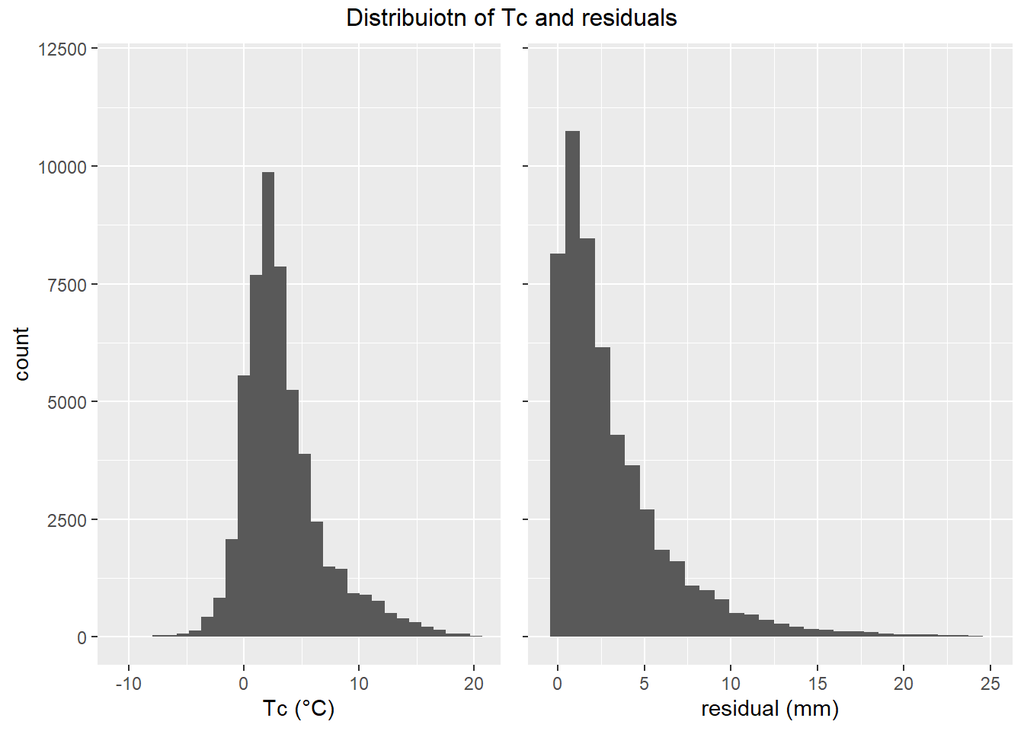

Seasonally, there does appear to be a ~6-year oscillation around the mean, even after 2011, when the SNODAS data are used:

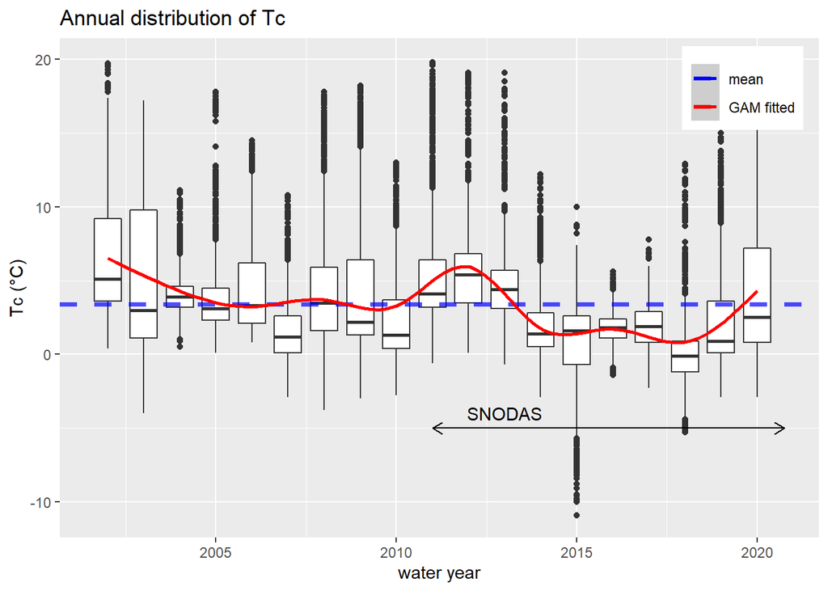

The overall mean $T_c$ sat within the inter-quartiles of the set of optimized critical temperatures for 12 of 19 seasons.

Operationally, when needing to apply $T_c$ to real-time $P$ estimates, the mean critical temperature of 3.4°C is used> This analysis will only apply to past seasons, once complete.

## Discussion

As a simple validation, annual total precipitation, averaged over the 2,813 sub-watersheds is compared with total precipitation interpolated from station data. Overall the 2 data sets are follow each other, with no obvious sign of the 6-year occillation mentionned above.

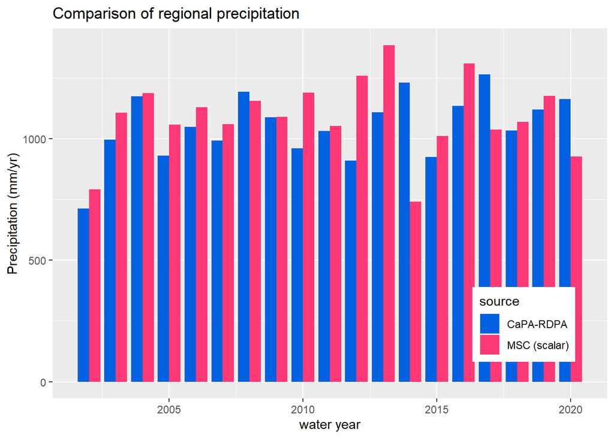

Overall, regional $T_c$ managed to remain close to the freezing point as would be expected. There are some rare $T_c$ outliers; however every optimum seemed to converge to negligible residuals (<percent annual precipitation).

Based on these results, the CaPA-RDPA precipitation field have been successfully parsed into the $P_R$ and $P_S$ components at the 6-hour time step, then aggregated to daily time steps.

### comparison with CCF model

The optimization routine was also performed without SNODAS, as a means of validating the [CCF model](https://owrc.github.io/interpolants/modelling/waterbudget/snowmeltCCF.html) used for data infill. Below show the negligeable difference in optimal $T_c$ selection and residuals.

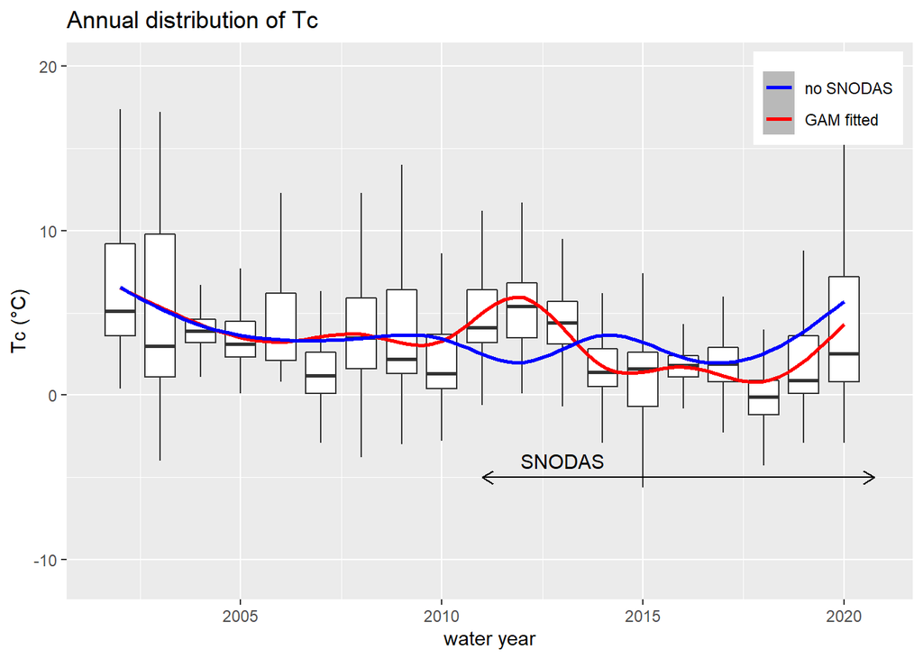

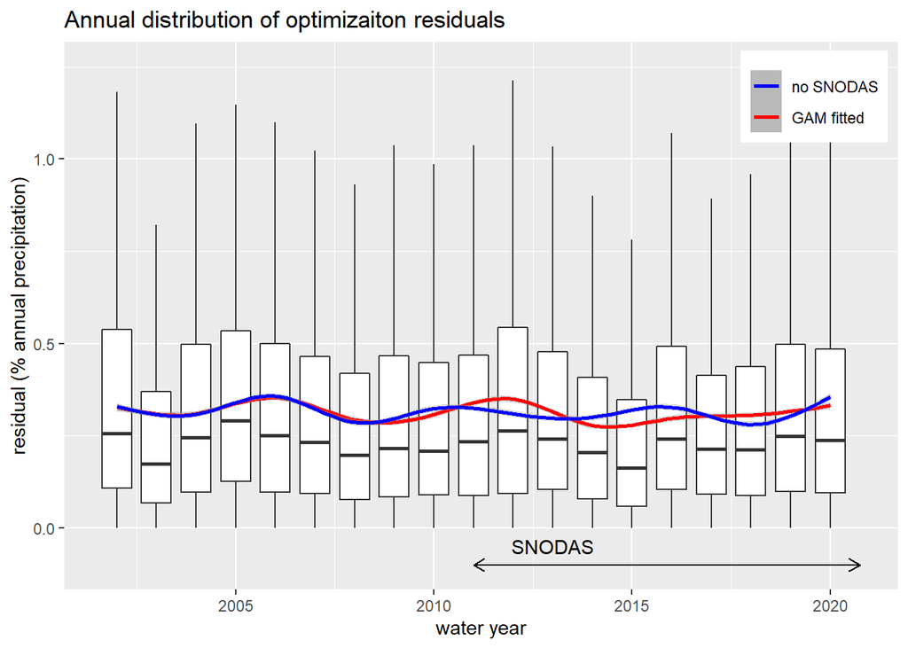

### $T_c$ distribution

Lastly, as a final validation step, annual $T_c$’s distributed across the ORMGP sub-watershed network is inspected for irregularities. Notice the increased resolution offered by SNODAS.

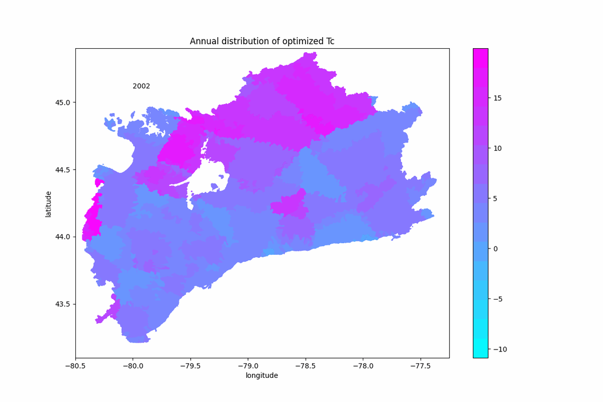

# Data files

The following data files used in the above analysis have been interpolated to the 2,813 sub-watersheds.

- [`202009301300-CaPA-RDPA.nc`](https://www.dropbox.com/s/aldla0vryo3wqgk/202009301300-CaPA-RDPA.nc?dl=1) 6-hourly $P$ 2002-2020
- [`202209271600-6hourlyBasin.nc`](https://www.dropbox.com/s/zq9i9cb4cawet9l/202209271600-6hourlyBasin.nc?dl=1) 6-hourly $T_a$, $p_a$, $r$, $\overline{u}$, $E_a$ 1989-2022
- [`202209271600-dailyBasin.nc`](https://www.dropbox.com/s/uddestk6u9tuawn/202209271600-dailyBasin.nc?dl=1) daily $T_n$, $T_x$, $P_R$, $P_S$, $P_M$ 1901-2022

# References

Oke, T.R., 1987. Boundary Layer Climates, 2nd ed. London: Methuen, Inc.